# Numerical Integration (Quadrature)

ENPC Course — Scientific Computing in Practice

## The Problem

**Objective: compute numerically**

$$I := \int_{\Omega} u(\mathbf{\boldsymbol{x}}) \, \mathrm d\mathbf{\boldsymbol{x}}$$
where $\Omega \subset {\mathbb{{R}}}^d$ and $u\colon \Omega \to {\mathbb{{R}}}$.

- For simplicity we focus on the **1D** case: $\Omega = [-1, 1] \subset {\mathbb{{R}}}$
- The general **1D** case on $[a,b]$ uses the bijection
  $$\begin{array}{rrcl}
  \zeta\colon &[-1, 1] &\to& [a, b] \\
  &y &\mapsto& \frac{b+a}{2} + \frac{b-a}{2} y
  \end{array}$$
  so that
  $$\int_{a}^{b} u(x) \, \mathrm dx
  = \int_{-1}^{1} u\bigl(\zeta(y)\bigr) \, \zeta'(y) \, \mathrm dy
  = \frac{b-a}{2}\int_{-1}^{1} u \circ \zeta (y) \, \mathrm dy,$$
- **Question:** can we approximate $I$ by a sum of the form

  $$\widehat I = \sum_{i=0}^n w_i \, u(x_i) \quad ?$$

## The Closed Newton-Cotes Method

**Main idea**

- Compute the polynomial interpolation $\widehat u$ of $u$ at equally spaced nodes $-1 = x_0 < x_1 < \dots < x_{n-1} < x_n = 1$.
- Then compute the approximation

  $$\widehat I \approx \int_{-1}^{1} \widehat u(x) \, \mathrm dx$$
- Explicit expression for the interpolating polynomial:
  $$\widehat u(x) = \sum_{i=0}^{n} u(x_i) \varphi_i(x),
  \qquad \text{where} \qquad
  \varphi_{i}(x) = \prod_{\substack{j = 0\\ j \neq i}}^{n} \frac {x - x_j} {x_i - x_j}.$$
- We deduce
  $$\widehat I
  = \int_{-1}^{1} \widehat u(x) \, \mathrm dx
  = \sum_{i=1}^n w_i u(x_i),
  \qquad \text{with} \qquad
  w_i := \int_{-1}^{1} \varphi_i(x) \, \mathrm dx.$$

## Newton-Cotes Weights by Symbolic Computation

```julia
using SymPy
@syms x

nodes(n) = Sym[-1 + 2i//n for i in 0:n]

lagrange(nodes, i) = prod(x .- nodes[1:end .!= i]) /
                     prod(nodes[i] .- nodes[1:end .!= i])

for n ∈ (1,2,4)
  nd = nodes(n) ; println("**********") ; @show n ; println(nd)
  println([integrate(lagrange(nd, i),(x, -1, 1)) for i ∈ eachindex(nd)])
end
```

```
**********
n = 1
Sym[-1, 1]
Sym{PyCall.PyObject}[1, 1]
**********
n = 2
Sym[-1, 0, 1]
Sym{PyCall.PyObject}[1/3, 4/3, 1/3]
**********
n = 4
Sym[-1, -1/2, 0, 1/2, 1]
Sym{PyCall.PyObject}[7/45, 32/45, 4/15, 32/45, 7/45]
```

$$w_i := \int_{-1}^{1} \varphi_i(x) \, \mathrm dx$$

$$~$$

| Method | Integration formula |
| --- | --- |
| Trapezoidal | $\widehat I = u(-1) + u(1)$ |
| Simpson | $\widehat I = \frac{1}{3} u(-1) + \frac{4}{3} u(0) + \frac{1}{3} u(1)$ |
| Boole | $\widehat I = \frac{7}{45} u(-1) + \frac{32}{45} u\left(-\frac{1}{2}\right) + \frac{4}{15} u(0) + \frac{32}{45} u\left(\frac{1}{2}\right) + \frac{7}{45} u(1)$ |

$$~$$

Source: [B. K. Nguyen’s course](https://nguyen.me.uk)

## The Closed Newton-Cotes Method: Examples

$$~$$

| $n$ | $d$ | Method | Integration formula |
| --- | --- | --- | --- |
| 1 | 1 | Trapezoidal | $\widehat I = u(-1) + u(1)$ |
| 2 | 3 | Simpson | $\widehat I = \frac{1}{3} u(-1) + \frac{4}{3} u(0) + \frac{1}{3} u(1)$ |
| 4 | 5 | Boole | $\widehat I = \frac{7}{45} u(-1) + \frac{32}{45} u\left(-\frac{1}{2}\right) + \frac{4}{15} u(0) + \frac{32}{45} u\left(\frac{1}{2}\right) + \frac{7}{45} u(1)$ |

$$~$$

- $n =$ polynomial **construction degree**
- $d =$ **degree of precision** $=$ the highest polynomial degree such that integration is exact

  $n=2 ⇒ d=3$ since $\int_{x=-1}^1 x^3 \mathrm dx = \frac{1}{3} (-1)^3 + \frac{4}{3} (0)^3 + \frac{1}{3} (1)^3=0$
- In principle, integration rules of arbitrarily high degree can be constructed by increasing the number of integration nodes.

## Failure of the Newton-Cotes Method

… even with many nodes, since polynomial interpolation does not always converge.

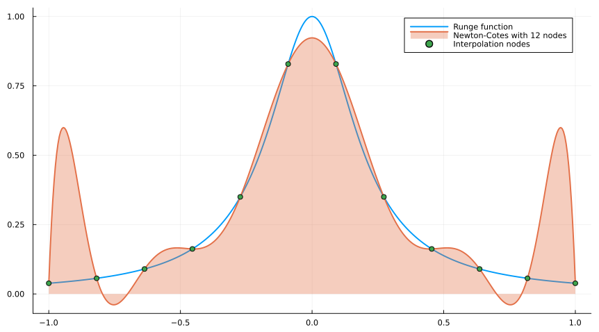

```julia
import Polynomials
import Plots
Plots.default(linewidth=2)
n = 12 ; X = LinRange(-1, 1, n)
f(x) = 1 / (1 + 25 * x^2)
p = Polynomials.fit(X, f.(X))
x = -1:0.005:1
Plots.plot(x, f.(x), label="Runge function")
Plots.plot!(legend=:topright, size=(900,500))
Plots.plot!(x, p.(x), fillrange = 0 .* x, fillalpha = 0.35, label="Newton-Cotes with " * string(n) * " nodes")
Plots.scatter!(X, f.(X), label="Interpolation nodes")
```

Source: [B. K. Nguyen’s course](https://nguyen.me.uk)

## Composite Newton-Cotes Method

**Idea: use piecewise interpolation**

- Recall on the error for polynomial interpolation with equally spaced nodes
  $$\fcolorbox{bleu_C}{bleu_light_C}{$
  e_n(x) := u(x) - \widehat u(x) = \frac{u^{(n+1)}(\xi)}{(n+1)!} (x-x_0) \dotsc (x - x_n)
  $}$$

  $$\fcolorbox{bleu_C}{bleu_light_C}{$
  \begin{align}
  &E_n := \sup_{x ∈ [a, b]} \bigl\lvert e_n(x) \bigr\rvert \leqslant\frac{C_{n+1}}{4(n+1)}
  \left(\frac{b-a}{n} \right)^{n+1}\\
  &\text{with }
  C_{n+1} = \sup_{x ∈ [a, b]} \left\lvert u^{(n+1)}(x) \right\rvert
  \text{ and }
  h = \frac{b-a}{n}
  \end{align}
  $}$$
- Recall on the error for piecewise interpolation
  - interval $[a,b]$ discretized with $n+1$ nodes, $h=\frac{b-a}{n}$
  - polynomial of degree $m$ on $[x_{i},x_{i+1}]$
  - error
    $$\fcolorbox{bleu_C}{bleu_light_C}{$
    \sup_{x ∈ [x_{i},x_{i+1}]} \bigl\lvert e_n(x) \bigr\rvert \leqslant\frac{C_{m+1}}{4(m+1)} \left(\frac{h}{m}\right)^{m+1}
    $}$$
  - $n$ is meant to tend to infinity, not $m$
  - $m$ is kept small, so the error is uniformly bounded by $C h^{m+1}$

**Composite trapezoidal rule $\color{red}{m=1}$**

- $n+1$ equally spaced nodes $a=x_0< x_1< \dotsc < x_n=b$, step $h=\frac{b-a}{n}$
- Trapezoidal integration on $[x_{i},x_{i+1}]$

  $$\int_{x_i}^{x_{i+1}} u(x) \, \mathrm dx
  = \frac{h}{2} \int_{-1}^{1} u \circ \zeta (y) \, \mathrm dy
  \approx \frac{h}{2} \bigl( u \circ \zeta(-1) + u \circ \zeta(1) \bigr)
  = \frac{h}{2} \bigl(u(x_i) + u(x_{i+1})\bigr)$$
- Applied on each subinterval

  $$\begin{align}
  \int_{a}^{b} u(x) \, \mathrm dx
  &= \sum_{i=0}^{n-1} \int_{x_i}^{x_{i+1}} u(x) \, \mathrm dx
  \approx
  \frac{h}{2}\sum_{i=0}^{n-1} \bigl( u(x_i) + u(x_{i+1}) \bigr) \\
  &= \frac{h}{2} \bigl( u(x_0) + 2 u(x_1) + 2 u(x_2) + \dotsb + 2 u(x_{n-2}) + 2 u(x_{n-1}) + u(x_n) \bigr)
  \end{align}$$

**Exercise: prove the following theorem**

Assume $u \in \mathcal{C}^2([a, b])$ and $\widehat I_h$ denotes the trapezoidal approximation of the integral $I$ of $u$. Then
$$\bigl\lvert I - \widehat I_h \bigr\rvert
\leqslant\frac{b-a}{12} C_2 h^2,
\qquad
C_2 := \sup_{\xi \in [a, b]} \lvert u''(\xi)\rvert$$

```julia
function composite_trapezoidal(u, a, b, n)
    h = (b-a)/n ; xᵢ = LinRange(a, b, n+1) ; uₓ = u.(xᵢ)
    return (h/2) * sum([uₓ[1]; uₓ[end]; 2uₓ[2:end-1]])
end
4composite_trapezoidal(x->1/(1+x^2), 0, 1, 50)
```

```
3.1415259869232535
```

## Composite Simpson’s Rule

**Construction of the rule**

- $n+1$ equally spaced nodes $a=x_0< x_1< \dotsc < x_n=b$, step $h=\frac{b-a}{n}$
- $n$ even ⇒ even number of intervals and odd number of nodes
- Splitting
  $$\int_{a}^{b} u(x) \, \mathrm dx
  =\sum_{i=0}^{n/2-1} \int_{x_{2i}}^{x_{2i+2}} u(x) \, \mathrm dx$$
- Recall: Simpson on $[-1,1]$
  $$\int_{-1}^{1} u(x) \, \mathrm dx \approx \frac{1}{3} \bigl(u(-1) + 4 u(0) + u(1)\bigr)$$
- Hence on $[x_{2i},x_{2i+2}]$
  $$\begin{align}
  \int_{x_{2i}}^{x_{2i+2}} u(x) \, \mathrm dx & \approx \frac{x_{2i+2}-x_{2i}}{2} × \frac{1}{3} \Bigl(u(x_{2i}) + 4 u(x_{2i+1}) + u(x_{2i+2})\Bigr)\\
  & \approx \frac{h}{3} \Bigl(u(x_{2i}) + 4 u(x_{2i+1}) + u(x_{2i+2})\Bigr)
  \end{align}$$
- Composite Simpson’s rule
  $$\widehat I_h \approx
  \frac{h}{3} \Bigl( u(x_0) + 4 u(x_1) + 2 u(x_2) + 4 u(x_3) + 2 u(x_4) + \dotsb + 2 u(x_{n-2}) + 4 u(x_{n-1}) + u(x_n)\Bigr)$$

**Error control**

Assume $u \in \mathcal{C}^4([a, b])$. Then
$$\bigl\lvert I - \widehat I_h \bigr\rvert
\leqslant\frac{b-a}{180} C_4 h^4,
\qquad
C_4 := \sup_{\xi \in [a, b]} \lvert u^{(4)}(\xi)\rvert$$

- Proof given in the lecture notes.
- The proof uses the fact that the degree of precision of Simpson’s rule is 3 and not 2.

## Method with Non-Equally Spaced Nodes: Gaussian Quadrature

**Problem**

- Newton-Cotes integration ⇒ fixed nodes, only degrees of freedom = weights
- For a degree of precision of $2n+1$ with Newton-Cotes, $2n+2$ nodes are needed
- If nodes are also optimized, one can expect a degree of precision of $2n+1$ with $n+1$ nodes and $n+1$ weights, i.e. $2n+2$ unknowns and as many equations
  $$\sum_{i=0}^{n} w_i x_i^{d} = \int_{-1}^{1} x^d \, \mathrm dx, \qquad d = 0, \dotsc, 2n+1$$
- But there is a more efficient method to identify nodes and weights…

**Orthogonal polynomials**

- Generalization to computing the integral over an interval $\mathcal{I}$ (not necessarily bounded), weighted by a continuous function $w$ with $w(x)>0$ for all $x\in\mathcal{I}$.

  We want to find $(r_i)_{(i=0,\dots,n)}$ and $(w_i)_{(i=0,\dots,n)}$ such that
  $$\int_{\mathcal{I}} P(x) w(x) \mathrm dx = \sum_{i=0}^{n} w_i P(r_i)
  \qquad
  \forall P \in{\mathbb{{R}}}_{2n+1}[X]$$
- We introduce the inner product
  $$\begin{array}{rccl}
  ⟨•,•⟩_w :&
  \mathcal{C}(\mathcal{I})×\mathcal{C}(\mathcal{I})&→&{\mathbb{{R}}}\\
  &(f,g)&↦&⟨f,g⟩_w=\int_{\mathcal{I}} f(x) g(x) w(x) \mathrm dx
  \end{array}$$
- Gram-Schmidt procedure on polynomials $1$, $X$, $X^2$, … ⇒ orthonormal polynomials $(φ_i)_{(i=0,1,\ldots)}$ with $\mathrm{deg}(φ_i)=i$ and hence $⟨φ_i,φ_j⟩_w=δ_{ij}$

**Theoretical construction of points and weights**

- Recurrence relations $∀ i ∈ \{0,1,\ldots\} \quad X φ_i = α_i φ_{i-1} + β_i φ_i + α_{i+1} φ_{i+1}$

  with $α_i=⟨X φ_i, φ_{i-1}⟩_w$, $β_i=⟨X φ_i, φ_i⟩_w$ and $φ_{-1}=0$ (by convention)

  **Proof sketch**

  ∙ Note that $X φ_i$, of degree $i+1$, decomposes as $X φ_i=\sum_{k=0}^{i+1} γ_k φ_k$

  ∙ Identify $γ_k=⟨X φ_i, φ_k⟩_w=⟨φ_i, X φ_k⟩_w$, zero if $k+1<i$ (i.e. $k<i-1$)

  **Linear system**

  $$\underbrace{
  \begin{pmatrix}
  x φ_0(x) \\
  x φ_1(x) \\
  \vdots \\
  x φ_{n-1}(x) \\
  x φ_n(x)
  \end{pmatrix}
  }_{x \mathsf{Φ}(x)}
  =
  \underbrace{
  \begin{pmatrix}
  β_0 & α_1 \\
  α_1 & β_1 & α_2 & & 0 \\
  & & \ddots & \ddots & \ddots \\
  & 0 & & α_{n-1} & β_{n-1} & α_n \\
  & & & & α_n & β_n
  \end{pmatrix}
  }_{\mathsf A}
  \underbrace{
  \begin{pmatrix}
  φ_0(x) \\
  φ_1(x) \\
  \vdots \\
  φ_{n-1}(x) \\
  φ_n(x)
  \end{pmatrix}
  }_{\mathsf{Φ}(x)}
  +
  \begin{pmatrix}
  0 \\
  0 \\
  \vdots \\
  0 \\
  α_{n+1} φ_{n+1}(x)
  \end{pmatrix}$$
- Let $r_0, r_1, \ldots, r_n$ be the (distinct) roots of $φ_{n+1}$.

  $(\mathsf{Φ}(r_i))_{(i=0,\dots,n)}$ forms an orthogonal basis (with respect to the canonical inner product of $\mathbb{R}^{n+1}$) diagonalizing $\mathsf A$.

  **Proof sketch**

  ∙ Consider $∫_{\mathcal{I}}φ_{n+1}(x)(x-x_1)\ldots(x-x_k) w(x) \mathrm dx$ if $φ_{n+1}$ changes sign at $(x_i)_{(i=1,\dots,k<n+1)}$

  ∙ The orthogonality of the diagonalizing basis follows from the symmetry of $\mathsf A$
- We then have $\mathsf{D}=\mathsf{P}\mathsf{P}^T$ with $\mathsf{D}$ diagonal and
  $$\mathsf{P} =
  \begin{pmatrix}
  φ_0(r_0) & φ_1(r_0) & \dots & φ_n(r_0) \\
  φ_0(r_1) & φ_1(r_1) & \dots & φ_n(r_1) \\
  \vdots & \vdots & \dots & \vdots \\
  φ_0(r_n) & φ_1(r_n) & \dots & φ_n(r_n)
  \end{pmatrix}
  \qquad
  d_{ii}=\lVert\mathsf{Φ}(r_i)\rVert^2=\sum_{j=0}^n φ_j(r_i)^2$$
- We introduce the inner product on the space of polynomials of degree at most $n$
  $$\begin{array}{rccl}
  ⟨•,•⟩_{n+1} :&
  \mathbb{R}_n[X]×\mathbb{R}_n[X]&→&\mathbb{R} \\
  &(P,Q)&↦&⟨P,Q⟩_{n+1}=\sum_{i=0}^n w_i P(r_i) Q(r_i)
  \end{array}
  \quad\textrm{ with } w_i=\frac{1}{d_{ii}}$$

  $(φ_i)_{(i=0,\ldots,n)}$ is an orthonormal basis for $⟨•,•⟩_{n+1}$ since $\mathsf{P}^T\mathsf{D}^{-1}\mathsf{P}=\mathsf{I}$
- $∀ (P,Q)∈\mathbb{R}_n[X]^2 \quad ⟨P,Q⟩_{w}=⟨P,Q⟩_{n+1}$ then $Q=1$ ⇒ $\int_{\mathcal{I}} P(x) w(x) \mathrm dx = \sum_{i=0}^{n} w_i P(r_i)$
- True for $P∈\mathbb{R}_{2n+1}[X]$ by Euclidean division $P=φ_{n+1}Q+R$ with $\mathrm{deg}(Q)$ and $\mathrm{deg}(R)≤n$

## Examples of Gaussian Quadrature

$$\int_{\mathcal{I}} P(x) {\color{red}w(x)} \, \mathrm dx=\sum_{i=0}^{n} w_i P(r_i)
\qquad
\forall P \in{\mathbb{{R}}}_{2n+1}[X]$$

| Integration domain | Weight function $w(x)$ | Orthogonal polynomial family |
| --- | --- | --- |
| $[–1, 1]$ | 1 | Legendre |
| $]–1, 1[$ | $(1-x)^α (1+x)^β$, $α,β>-1$ | Jacobi |
| $]–1, 1[$ | $\frac{1}{\sqrt{1-x^2}}$ | Chebyshev (first kind) |
| $]–1, 1[$ | $\sqrt{1-x^2}$ | Chebyshev (second kind) |
| ${\mathbb{{R}}}^+$ | $\mathop{\mathrm{e}}^{-x}$ | Laguerre |
| ${\mathbb{{R}}}$ | $\mathop{\mathrm{e}}^{-x^2}$ | Hermite |

## Concrete Implementation

**Method summary**

$$\int_{\mathcal{I}} P(x) w(x) \, \mathrm dx=\sum_{i=0}^{n} w_i P(r_i)
\qquad
\forall P \in{\mathbb{{R}}}_{2n+1}[X]$$

- Identify the family of orthonormal polynomials up to degree $n$ satisfying $X φ_i = α_i φ_{i-1} + β_i φ_i + α_{i+1} φ_{i+1}$
- Form the matrix $\mathsf A$
  $$\mathsf A=
  \begin{pmatrix}
  β_0 & α_1 \\
  α_1 & β_1 & α_2 & & 0 \\
  & & \ddots & \ddots & \ddots \\
  & 0 & & α_{n-1} & β_{n-1} & α_n \\
  & & & & α_n & β_n
  \end{pmatrix}$$
- Points $r_i$ given by the eigenvalues of $\mathsf A$
- Weights $w_i=\frac{1}{\lVert\mathsf{Φ}(r_i)\rVert^2}$ with $\mathsf{Φ}(r_i)=\left(φ_0(r_i),\ldots,φ_n(r_i)\right)^T$ eigenvector of $\mathsf A$

  ⚠ Eigenvectors from diagonalization algorithms are defined up to scaling (e.g. normalized w.r.t. the Euclidean norm in $\mathbb{R}^{n+1}$).

  This can be handled using the known value $φ_0(r_i)=\mathsf{Φ}(r_i)[1]$.

  Thus if $(\mathsf{E}_i)_{(i=0,\ldots,n)}$ are eigenvectors of $\mathsf{A}$, we obtain

  $$w_i=\frac{1}{\lVert\mathsf{Φ}(r_i)\rVert^2}=\frac{\mathsf{E}_i[1]^2}{φ_0(r_i)^2}\,\frac{1}{\lVert\mathsf{E}_i\rVert^2}$$
- Other identification methods (e.g. weights via Lagrange polynomials)

**Application to Gauss-Legendre: $\mathcal{I}=[-1,1]$ and $w=1$**

- Rodrigues formula $L_i(x)=\frac{1}{i!2^i}\frac{\mathrm{d}^i}{\mathrm{d} x^i}\left((x^2-1)^i\right)$
- The degree of $L_i$ is $i$ and $L_i$ has the same parity as $i$: $L_i(-x)=(-1)^i L_i(x)$
- The leading coefficient of $L_i$ is $\frac{(2i)!}{i!^2 2^i}=\frac{{2i \choose i}}{2^i}$
- By Leibniz’s rule, $L_i(x)=\frac{1}{2^i} \sum_{k=0}^i {i\choose k}^2 (x+1)^{i-k} (x-1)^k$, hence $L_i(1)=1$ and $L_i(-1)=(-1)^i$
- $L_i$ is orthogonal to every polynomial in $\mathbb{R}_{i-1}[X]$ with respect to $⟨•,•⟩_w$

  **Proof hint**

  Apply $i$ integrations by parts, observing that $\frac{\mathrm{d}^k}{\mathrm{d} x^k}\left((x^2-1)^n\right)$ evaluated at $1$ and $-1$ is zero for $k<i$
- $\lVert L_i \rVert^2=⟨L_i,L_i⟩_w=\frac{2}{2i+1}$

  **Proof hint**

  ∙ Note that $⟨L_i,L_i⟩_w=\frac{(2i)!}{i!^2 2^i}⟨L_i,X^i⟩$, then integrate by parts

  ∙ Use Wallis’s integral $\int_{θ=0}^{\frac{π}{2}}\sin^{2i+1}{θ}\,\mathrm dθ=\frac{i!^2 2^{2i}}{(2i+1)!}$
- Recurrence: $L_0=1, \quad L_1=X, \quad (2i+1)X L_i = i L_{i-1} + (i+1)L_{i+1}\;(i≥1)$

  **Proof hint**

  Consider an appropriate decomposition of $X L_i$, exploiting orthogonality, parity and leading term properties
- $φ_i=\frac{L_i}{\lVert L_i \rVert}=\sqrt{\frac{2i+1}{2}}L_i$ ⇒ $φ_0=\frac{1}{\sqrt{2}}, \quad φ_1=\sqrt{\frac{3}{2}}X, \quad X φ_i = α_i φ_{i-1} + α_{i+1} φ_{i+1} \;\textrm{ with } α_i=\frac{i}{\sqrt{4i^2-1}}$

```julia
using LinearAlgebra
gauss_legendre(n) = (E=eigen(SymTridiagonal(zeros(n+1),[i/sqrt(4i^2-1) for i ∈ 1:n])) ;
                                                      (E.values, 2(E.vectors[1,:]).^2) )
for n ∈ 0:2 x,w=gauss_legendre(n); println("n=$n xᵢ=$(round.(x;digits=8)) wᵢ=$(round.(w;digits=8))") end
```

```
n=0 xᵢ=[0.0] wᵢ=[2.0]
n=1 xᵢ=[-0.57735027, 0.57735027] wᵢ=[1.0, 1.0]
n=2 xᵢ=[-0.77459667, 0.0, 0.77459667] wᵢ=[0.55555556, 0.88888889, 0.55555556]
```